# Probability Distributions & Hypothesis Tests

# Anova

#### About F Distribution

To perform an Anova Test, we need to compare two kinds of variation, variation between sample means & the variation within each of the sample means.

We combine all of this into a single statistic and that statistic is called F Statistic.

#### How to Calculate Anova:: Steps

1. Find out the Degrees of Freedom for Within & Between
2. DFn - Degrees of Freedom Between (k-1)
3. DFd - Degrees of Freedom Within (n-k)
4. Find the Mean of all the Columns & Grand Mean (Mean of all the Data Points)
5. Find the Sum of Squares Total(SST): Sum of Difference of Data Points & Grand Mean
6. Find the Sum of Squares Within(SSW): Sum of Difference of Data Points & resp Sample Means.
7. Sum of Squares Between = SST - SSW
8. Mean Squares Between = SSB/Dfn
9. Mean Square Within = SSW/DFd
10. Find the Critical Value and F Test Statistic (FStats = MSb/MSw),Compare and Conclude.

```python
# Critical Value
stats.f.ppf(0.95, dfn = 2, dfd = 6) # LOS - 0.05
```

```
5.143252849784718
```

```python
df = pd.DataFrame({"G1":[1,2,5], "G2":[2,4,2], "G3":[2,3,4]})
```

```python
df
```

|  | G1 | G2 | G3 |
| --- | --- | --- | --- |
| 0 | 1 | 2 | 2 |
| 1 | 2 | 4 | 3 |
| 2 | 5 | 2 | 4 |

```python
# F test and Pvalue
stats.f_oneway(df["G1"], df["G2"], df["G3"])

# Since the PValue > 0.05, Fail to Reject the Ho.
```

```
F_onewayResult(statistic=0.049999999999999996, pvalue=0.9516215013591449)
```

```python
# If this data has Equal Variance, any other way other than anova
# LEVENE's Test
# Ho: That the variance across is same
# H1: That the Variance is not 0./ H0 is False.

stats.levene(df["G1"], df["G2"], df["G3"])

# Conclusion: Samples Come from a Pop with the Same Variance.
```

```
LeveneResult(statistic=0.3333333333333333, pvalue=0.7289999999999998)
```

Consider the monthly income of members from three different gyms - fitness centers given below:

- Gym 1 (n = 22): [60, 66, 65, 55, 62, 70, 51, 72, 58, 61, 71, 41, 70, 57, 55, 63, 64, 76, 74, 54, 58, 73]
- Gym 2 (n = 18): [56, 65, 65, 63, 57, 47, 72, 56, 52, 75, 66, 62, 68, 75, 60, 73, 63, 64]
- Gym 3 (n = 23): [67, 56, 65, 61, 63, 59, 42, 53, 63, 65, 60, 57, 62, 70, 73, 63, 55, 52, 58, 68, 70, 72, 45]

Using ANOVA, test whether the mean monthly income is equal for each Gym

```python
Gym_1 = [60, 66, 65, 55, 62, 70, 51, 72, 58, 61, 71, 41, 70, 57, 55, 63, 64, 76, 74, 54, 58, 73]
Gym_2 = [56, 65, 65, 63, 57, 47, 72, 56, 52, 75, 66, 62, 68, 75, 60, 73, 63, 64]
Gym_3 = [67, 56, 65, 61, 63, 59, 42, 53, 63, 65, 60, 57, 62, 70, 73, 63, 55, 52, 58, 68, 70, 72, 45]
```

```python
gyms = pd.DataFrame({"Gym01":pd.Series(Gym_1), "Gym02":pd.Series(Gym_2), "Gym03":pd.Series(Gym_3)})
```

```python
# Ho: Tha the Income is Same Across All Gyms
# H1: That the Income is not Same Across All Gyms

stats.f_oneway(Gym_1, Gym_2, Gym_3)

# Since  P Value is > 0.05,  We Fail to Reject the Ho.
```

```
F_onewayResult(statistic=0.4970745666663714, pvalue=0.6107903864000767)
```

```python
# Manipulate it in DF
income = pd.DataFrame()

df1 = pd.DataFrame({"Gym": '1', "M_Income": Gym_1})
df2 = pd.DataFrame({"Gym": '2', "M_Income": Gym_2})
df3 = pd.DataFrame({"Gym": '3', "M_Income": Gym_3})

income = income.append(df1)
income = income.append(df2)
income = income.append(df3)
```

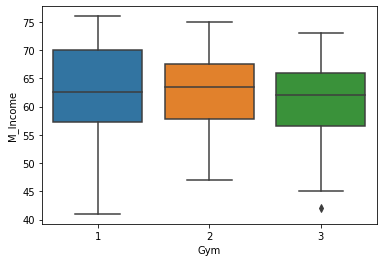

```python
sns.boxplot(x = "Gym", y = "M_Income", data = income)
```

```python
income.head()
```

|  | Gym | M_Income |
| --- | --- | --- |
| 0 | 1 | 60 |
| 1 | 1 | 66 |
| 2 | 1 | 65 |
| 3 | 1 | 55 |
| 4 | 1 | 62 |

```python
import statsmodels.api as sm
from statsmodels.formula.api import ols

model = ols('M_Income~Gym', data = income).fit() # Ordinary Least Square Method
```

```python
# model.summary() ~ Regression Table Output

# Anova Table
table = sm.stats.anova_lm(model)
print(table)
```

```
            df       sum_sq    mean_sq         F   PR(>F)
Gym        2.0    66.614123  33.307061  0.497075  0.61079
Residual  60.0  4020.370004  67.006167       NaN      NaN
```

```python
stats.f_oneway(Gym_1, Gym_2, Gym_3)

# Conclusion: Since P Value is Greater than 0.05, Hence we fail to reject the Ho.
```

```
F_onewayResult(statistic=0.4970745666663714, pvalue=0.6107903864000767)
```

National Transportation Safety Board (NTSB) examines the safety of compact cars, midsize cars and full-size cars. Using the data given below, test whether the mean pressure applied to the driver's head during a crash test is equal for each types of car at 5% level of significance.

- meanpressure compact_car = [643, 655,702]
- meanpressure midsize_car = [469, 427, 525]
- meanpressure fullsize_car = [484, 456, 402]

```python
meanpressure_compact_car = [643, 655,702] # Hatchback
meanpressure_midsize_car = [469, 427, 525] # Sedan
meanpressure_fullsize_car = [484, 456, 402] # SUV
```

```python
# Mean and SD of the Data
print("The Mean of Compact Cars is ", np.mean(meanpressure_compact_car), "And The S.D. is ",
      np.std(meanpressure_compact_car, ddof = 1))

print("The Mean of Midsize Cars is ", np.mean(meanpressure_midsize_car), "And The S.D. is ",
      np.std(meanpressure_midsize_car, ddof = 1))

print("The Mean of FullSize Cars is ", np.mean(meanpressure_fullsize_car), "And The S.D. is ",
      np.std(meanpressure_fullsize_car, ddof = 1))
```

```
The Mean of Compact Cars is  666.6666666666666 And The S.D. is  31.182259913824932
The Mean of Midsize Cars is  473.6666666666667 And The S.D. is  49.166384179979445
The Mean of FullSize Cars is  447.3333333333333 And The S.D. is  41.68133075290823
```

```python
# DataFrame

pressure = pd.DataFrame()

# Local DF
hatch = pd.DataFrame({"Car_Type":"C", "Mean_Pressure":meanpressure_compact_car})
sedan = pd.DataFrame({"Car_Type":"M", "Mean_Pressure":meanpressure_midsize_car})
suv = pd.DataFrame({"Car_Type":"F", "Mean_Pressure":meanpressure_fullsize_car})

# Append Those DFs as Objects in a Fresh DataFrame Container.
pressure = pressure.append(hatch)
pressure = pressure.append(sedan)
pressure = pressure.append(suv)

pressure
```

|  | Car_Type | Mean_Pressure |
| --- | --- | --- |
| 0 | C | 643 |
| 1 | C | 655 |
| 2 | C | 702 |
| 0 | M | 469 |
| 1 | M | 427 |
| 2 | M | 525 |
| 0 | F | 484 |
| 1 | F | 456 |
| 2 | F | 402 |

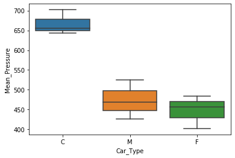

```python
# Boxplot ~ X axis:: Categorical, Y:: Numerical.

sns.boxplot(x = "Car_Type", y = "Mean_Pressure", data = pressure)
```

### Define Null and Alternate Hypothesis

- H0: Mean pressure of Compact = Mean Pressure of Midsize = Mean Pressure of Full Size
- H1: At Least one of the Mean Pressures for any car is different.

### Anova Table

```python
# Anova Table is generates using this library
import statsmodels.api as sm

# In order to fit anova on data, we use OLS (Regression Algorithm)
from statsmodels.formula.api import ols
```

```python
pressure.columns
```

```
Index(['Car_Type', 'Mean_Pressure'], dtype='object')
```

```python
# First Step: Fit Anova using OLS Method
# Step02: Generate the Anova Table: Sum of Sq, Mean Sq, DF, F Test Statistic, Pr(FTest)

# y~x: y is dependent variable where as ind var is x (3 levels: H, S, Suv)

model = ols('Mean_Pressure~Car_Type', data = pressure).fit() # Fiting the Model.

print(sm.stats.anova_lm(model))
```

```
           df        sum_sq       mean_sq          F    PR(>F)
Car_Type  2.0  86049.555556  43024.777778  25.175411  0.001207
Residual  6.0  10254.000000   1709.000000        NaN       NaN
```

### Conclusion:

Since the P Value is less than 0.05, we reject the Ho meaning that atleast for one car segment the mean pressure is different.

In order to identify the car segment 4 which the mean pressure is different, we will use a test that is called **Post Hoc Test**

- This test is used to determine which of the mean values are different.
- The test name is **TUKEY HSD TEST**

```python
from statsmodels.stats.multicomp import pairwise_tukeyhsd
print(pairwise_tukeyhsd(pressure["Mean_Pressure"], pressure["Car_Type"])) # One cat vs Num, Seq is Num, Cat
```

```
   Multiple Comparison of Means - Tukey HSD, FWER=0.05
=========================================================
group1 group2  meandiff p-adj    lower     upper   reject
---------------------------------------------------------
     C      F -219.3333 0.0015 -322.7791 -115.8876   True
     C      M    -193.0  0.003 -296.4458  -89.5542   True
     F      M   26.3333 0.7172  -77.1124  129.7791  False
---------------------------------------------------------
```

```python
# Quantity of Mobiles at different locs using different disc collected 20 days.
table1  = [['Loc','Dis0','Dis10','Dis20'], [ 1, 20, 28, 32], [ 2, 20, 19, 20],
  [ 1, 16, 23, 29 ],[ 2, 21, 27, 31 ],[ 1, 24, 25, 28 ],[ 2, 23, 23, 35 ],
  [ 1, 20, 31, 27 ],[ 2, 19, 30, 25 ],[ 1, 19, 25, 30 ],[ 2, 25, 25, 31 ],
  [ 1, 10, 24, 26 ],[ 2, 22, 21, 31 ],[ 1, 24, 28, 37 ],[ 2, 25, 33, 31 ],
  [ 1, 16, 23, 33 ],[ 2, 21, 26, 23 ],[ 1, 25, 26, 27 ],[ 2, 26, 22, 22 ],
  [ 1, 16, 25, 31 ],[ 2, 22, 28, 32 ],[ 1, 18, 22, 37 ],[ 2, 25, 24, 22 ],
  [ 1, 20, 24, 28 ],[ 2, 23, 23, 29 ],[ 1, 17, 26, 25 ],[ 2, 23, 26, 25 ],
  [ 1, 26, 28, 23 ],[ 2, 24, 16, 34 ],[ 1, 16, 21, 26 ],[ 2, 20, 30, 30 ],
  [ 1, 21, 27, 33 ],[2, 23, 22, 25 ],[ 1, 24, 25, 28 ],[ 2, 18, 16, 39 ],
  [ 1, 19, 20, 30 ],[ 2, 19, 25, 32 ],[ 1, 19, 26, 30 ],[ 2, 19, 34, 29 ],
  [ 1, 21, 26, 26 ],[ 2, 30, 23, 22 ]]
headers = table1.pop(0)

df1 = pd.DataFrame(table1, columns=headers)
df1.head()

# Location, Discount, Qtty: Disc Cat: 0, 10, 20
```

|  | Loc | Dis0 | Dis10 | Dis20 |
| --- | --- | --- | --- | --- |
| 0 | 1 | 20 | 28 | 32 |
| 1 | 2 | 20 | 19 | 20 |
| 2 | 1 | 16 | 23 | 29 |
| 3 | 2 | 21 | 27 | 31 |
| 4 | 1 | 24 | 25 | 28 |

### Problem Statement

We want to analyse that in the Sales of Mobile Phones, does the Discount offered & Location play a significant role or not.

- Ho: That the Quantity of Sale is Independent of the Discounts Offered & Location
- H1: Sale is Dependent on or Driven by the Discounts Offered & Location too.
- Note: There is no interaction between the Factors - Disc & Location.

```python
# Dataframe - Location, Discount: 0, 10, 20 & Qtty_Mobiles
# Two Way Anova is #of IVs. Here the IVs will be Disc & Location (They both are Cat)

d0_values = df1["Dis0"].values
d10_values = df1["Dis10"].values
d20_values = df1["Dis20"].values
locs = df1["Loc"].values
```

```python
# Lets Make a DF and Append it
d1 = pd.DataFrame({"Loc":locs, "Discount":"0", "Qtty":d0_values})
d2 = pd.DataFrame({"Loc":locs, "Discount":"10", "Qtty":d10_values})
d3 = pd.DataFrame({"Loc":locs, "Discount":"20", "Qtty":d20_values})
```

```python
sales = pd.DataFrame()
sales = sales.append(d1)
sales = sales.append(d2)
sales = sales.append(d3)
```

```python
sales.head()
```

|  | Loc | Discount | Qtty |
| --- | --- | --- | --- |
| 0 | 1 | 0 | 20 |
| 1 | 2 | 0 | 20 |
| 2 | 1 | 0 | 16 |
| 3 | 2 | 0 | 21 |
| 4 | 1 | 0 | 24 |

```python
import statsmodels.api as sm
from statsmodels.formula.api import ols

mobile_model = ols("Qtty~Discount+Loc+Discount:Loc", data = sales).fit()
print(sm.stats.anova_lm(mobile_model))
```

```
                 df       sum_sq     mean_sq          F        PR(>F)
Discount        2.0  1240.316667  620.158333  39.279968  1.055160e-13
Loc             1.0     7.008333    7.008333   0.443898  5.065930e-01
Discount:Loc    2.0    84.816667   42.408333   2.686085  7.246036e-02
Residual      114.0  1799.850000   15.788158        NaN           NaN
```

### Summary

- P value for disc is less than 0.05 and hence we reject the Ho meaning that Discounts have an impact on Sales.
- Location: P Value > 0.05 and thus, location has no significant impact on Sales.
- Interaction Effect: The Discount:Loc combined have not been able to create any impact on the sales.
- Conclusion - Thus, we can say that Sales is driven by the discount and no other factor.

## Chi Square

- In a bank atm, a manager wants to know if the no of people visiting atm is Same for all the Days.
- If the Food Offered in Any Restaurant is in sync with the customer's preference.
- Categories vs Categories | No Numbers | No Numerical Data in form of Revenue, Cost etc...
- The Data involved in Analysis is Frequency Data (value_counts)
- A Chi Square Test is a test of Hypothesis where two samples (categories) are tested for independence.
- It means if samples are independent, there is no effect.
- For e.g. in titanic, Passenger Class has an impact on Survival.
- Chi Square is a Non Paramteric Test. A NP Test is a test which does not have any assumptions about the data.
- Chi Square Test is based on differences between Observed Values and Expected Values sum[(Obs-Exp)^2/Exp]

### Question

A Bank has an ATM inside and it is available to the customers fro 7am to 6 pm. Monday to Friday. The manager wants to investigate if the no of transactions made in the ATM are same for 5 days.

Ho: No Difference H1: H0 is False

```python
no_of_users = [253, 197, 204, 279, 267] # Observed Values
days = ["Mon", "Tue", "Wed", "Thu", "Fri"]
```

```python
# Expected Values
np.sum(no_of_users)*1/5
```

```
240.0
```

```python
df = pd.DataFrame({"Days": days, "Users": no_of_users, "Exp_Values":np.sum(no_of_users)*1/5})
```

```python
df # sum[(Obs-Exp)^2/Exp] - Test statistic
```

|  | Days | Users | Exp_Values |
| --- | --- | --- | --- |
| 0 | Mon | 253 | 240.0 |
| 1 | Tue | 197 | 240.0 |
| 2 | Wed | 204 | 240.0 |
| 3 | Thu | 279 | 240.0 |
| 4 | Fri | 267 | 240.0 |

```python
df["Obs-Exp"] = df["Users"]-df["Exp_Values"]

df["Obs-Exp^2"] = df["Obs-Exp"]**2
```

```python
df
```

|  | Days | Users | Exp_Values | Obs-Exp | Obs-Exp^2 |
| --- | --- | --- | --- | --- | --- |
| 0 | Mon | 253 | 240.0 | 13.0 | 169.0 |
| 1 | Tue | 197 | 240.0 | -43.0 | 1849.0 |
| 2 | Wed | 204 | 240.0 | -36.0 | 1296.0 |
| 3 | Thu | 279 | 240.0 | 39.0 | 1521.0 |
| 4 | Fri | 267 | 240.0 | 27.0 | 729.0 |

```python
chiteststats = df["Obs-Exp^2"].sum()/240
```

```python
# Chi Square Critical Value - 0.99 Alpha : 0.01 and df = 4 (5-1) - 13.277
stats.chi2.isf(0.01, 4) #Alpha - use isf else provide CI and put PPF
```

```
13.276704135987625
```

```python
chiteststats>stats.chi2.isf(0.01, 4)
```

```
True
```

## Conclusion

- Since the test Stats > Critical value, we reject the Ho meaning that the No of Transaction happening at ATM are not same for all the days.

```python
# Python code: stats.chi2_contingency()
stats.chisquare(df["Users"], df["Exp_Values"])

# Results - We Reject the Ho.
```

```
Power_divergenceResult(statistic=23.183333333333337, pvalue=0.00011638214275705237)
```

```python
# Tips

tips = sns.load_dataset("tips")
```

```python
tips.head()
```

|  | total_bill | tip | sex | smoker | day | time | size |
| --- | --- | --- | --- | --- | --- | --- | --- |
| 0 | 16.99 | 1.01 | Female | No | Sun | Dinner | 2 |
| 1 | 10.34 | 1.66 | Male | No | Sun | Dinner | 3 |
| 2 | 21.01 | 3.50 | Male | No | Sun | Dinner | 3 |
| 3 | 23.68 | 3.31 | Male | No | Sun | Dinner | 2 |
| 4 | 24.59 | 3.61 | Female | No | Sun | Dinner | 4 |

- Ho: No of Customers who visit restaurant are same irrespective of the Gender
- H1: Ho is False
- Since both the Columns are Categorical in Nature, thus we can use Chi Square Test

```python
tips.sex.value_counts(), tips.day.value_counts()
```

```
(Male      157
 Female     87
 Name: sex, dtype: int64,
 Sat     87
 Sun     76
 Thur    62
 Fri     19
 Name: day, dtype: int64)
```

```python
data = pd.crosstab(tips.sex, tips.day)
```

```python
data
```

| day sex | Thur | Fri | Sat | Sun |
| --- | --- | --- | --- | --- |
| Male | 30 | 10 | 59 | 58 |
| Female | 32 | 9 | 28 | 18 |

```python
# Contingency Table to generate Statistic
# Test Stat Value, P Value, DF, Exp Value
teststats, pvalue, df, exp_freq = stats.chi2_contingency(data)

print(teststats)
print(pvalue)
print(df) # Degrees of Freedom = (r-1)*(c-1) = (2-1)*(4-1) = 3
print(exp_freq)
```

```
13.22200137240661
0.004180302092822257
3
[[39.89344262 12.22540984 55.9795082  48.90163934]
 [22.10655738  6.77459016 31.0204918  27.09836066]]
```

#### Conclusion: No of the Customers are not same irrespectie of the Gender

```python
# Load the Titanic Dataset
titanic = sns.load_dataset("titanic")
```

```python
titanic.head()
```

|  | survived | pclass | sex | age | sibsp | parch | fare | embarked | class | who | adult_male | deck | embark_town | alive | alone |
| --- | --- | --- | --- | --- | --- | --- | --- | --- | --- | --- | --- | --- | --- | --- | --- |
| 0 | 0 | 3 | male | 22.0 | 1 | 0 | 7.2500 | S | Third | man | True | NaN | Southampton | no | False |
| 1 | 1 | 1 | female | 38.0 | 1 | 0 | 71.2833 | C | First | woman | False | C | Cherbourg | yes | False |
| 2 | 1 | 3 | female | 26.0 | 0 | 0 | 7.9250 | S | Third | woman | False | NaN | Southampton | yes | True |
| 3 | 1 | 1 | female | 35.0 | 1 | 0 | 53.1000 | S | First | woman | False | C | Southampton | yes | False |
| 4 | 0 | 3 | male | 35.0 | 0 | 0 | 8.0500 | S | Third | man | True | NaN | Southampton | no | True |

```python
# who
titanic.who.value_counts()
```

```
man      537
woman    271
child     83
Name: who, dtype: int64
```

```python
# Ho: That the Survival is Independent of the Who (Gender) Column
# H1: That Survival is Depedendent on who you are

# Chi Square Test
tbl = pd.crosstab(titanic.survived, titanic.who)
tbl
```

| who survived | child | man | woman |
| --- | --- | --- | --- |
| 0 | 34 | 449 | 66 |
| 1 | 49 | 88 | 205 |

```python
# Chi Square Test

def chisquares(data):
    teststats, pvalue, df, exp_freq = stats.chi2_contingency(data)
    print("Test Stats is ", teststats)
    print("PValue is ", pvalue)
    if(pvalue<0.05):
        return("Reject Ho")
    else:
        return("Fail to Reject Ho")
```

```python
chisquares(tbl)

# Survival is Dependent on the Gender
```

```
Test Stats is  283.923050324233
PValue is  2.2227620817798914e-62
```

```
'Reject Ho'
```

```python
# Ho: That the PClass & Who are Independent
# H1: That PClass & Who Variable is Linked

data = pd.crosstab(titanic.pclass, titanic.who)
chisquares(data)

# Conclusion: Reject Ho means that Pclass and Who variable is linked.
```

```
Test Stats is  37.34293526831214
PValue is  1.5308103860076598e-07
```

```
'Reject Ho'
```

```python
titanic.head()
```

|  | survived | pclass | sex | age | sibsp | parch | fare | embarked | class | who | adult_male | deck | embark_town | alive | alone |
| --- | --- | --- | --- | --- | --- | --- | --- | --- | --- | --- | --- | --- | --- | --- | --- |
| 0 | 0 | 3 | male | 22.0 | 1 | 0 | 7.2500 | S | Third | man | True | NaN | Southampton | no | False |
| 1 | 1 | 1 | female | 38.0 | 1 | 0 | 71.2833 | C | First | woman | False | C | Cherbourg | yes | False |
| 2 | 1 | 3 | female | 26.0 | 0 | 0 | 7.9250 | S | Third | woman | False | NaN | Southampton | yes | True |
| 3 | 1 | 1 | female | 35.0 | 1 | 0 | 53.1000 | S | First | woman | False | C | Southampton | yes | False |
| 4 | 0 | 3 | male | 35.0 | 0 | 0 | 8.0500 | S | Third | man | True | NaN | Southampton | no | True |

```python
# Ho: Passenger Class has no role in Survival
# H1: Passenger Class has a Significant Role in Survival

tbl = pd.crosstab(titanic.pclass, titanic.survived)
chisquares(tbl)

# Conclusion: Pclass has a Role in Survival.
```

```
Test Stats is  102.88898875696056
PValue is  4.549251711298793e-23
```

```
'Reject Ho'
```

[figure not shown]

```python
# Ho: Embarked has nothing to do with the Survival.
# H1: embarked has something to do with the survival

g = sns.FacetGrid(titanic, col = "survived")
g.map(sns.countplot, "embarked", color = "hotpink") # w can try plt.hist or any plotting function
```

```python
embark = pd.crosstab(titanic.embarked, titanic.survived)
chisquares(embark)

# Conclusion: Embarked variable is important for survival.
```

```
Test Stats is  26.48914983923762
PValue is  1.769922284120912e-06
```

```
'Reject Ho'
```

A1 airlines operated daily flights to several Indian cities. The operations manager believes that 30% of their passengers prefer vegan food, 45% prefer vegetarian food , 20% prefer non-veg food 5% request for Jain food.

A sample of 500 passengers was chosen to analyse the food preferences and the data is shown in the following table:

|  | Food type | Vegan | Vegetarian | Non-Vegetarian | Jain |
| --- | --- | --- | --- | --- | --- |
| Number of passengers |  | 190 | 185 | 90 | 35 |

At 5% level of significance, can you confirm that the meal preference is as per the belief of the operations manager?

- Ho: Meal Preference is as perceived by the Ops Manager
- H1: Meal Preference is different from the perceived ratios

```python
# vegan = 0.30, Veggies = 0.45, Non veg = 0.20 and Jain Food = 0.05

obs = [190, 185, 90, 35]

total_pass = np.sum(obs)

# expected values
exp = [total_pass*0.30, total_pass*0.45, total_pass*0.20, total_pass*0.05]

# Chi Square

stats.chisquare(obs, exp)
```

```
Power_divergenceResult(statistic=22.77777777777778, pvalue=4.492718590376291e-05)
```

### Conclusion

Since the PValue is less than 0.05, we reject the Ho meaning that the perceived ratio by the Ops Manager is different and not what he thought.

### Example: 2

The table below contains the number of perfect, satisfactory and defective products are manufactured by both male and female.

| Gender | Perfect | Satisfactory | Defective |
| --- | --- | --- | --- |
| Male | 138 | 83 | 64 |
| Female | 64 | 67 | 84 |

Do these data provide sufficient evidence at the 5% significance level to infer that there are differences in quality among genders (Male and Female)?

- Ho: Quality_Of_Prod(males) = Quality of Prod(Females). There is no difference in quality of products made by m & f
- H1: Quality_Of_Prod(males) != Quality of Prod(Females). It means there is significant difference.

```python
data = np.array([[138, 83, 64], [64, 67, 84]])

chisquares(data)

# Conclusion: Reject Ho as there is a significant difference between the quality of products made by m & fs.
```

```
Test Stats is  22.152468645918482
PValue is  1.547578021398957e-05
```

```
'Reject Ho'
```

A University conducted a survey of its recent graduates to collect demographic and health information for future planning purposes as well as to assess students' satisfaction with their undergraduate experiences. The survey revealed that a substantial proportion of students were not engaging in regular exercise, many felt their nutrition was poor and a substantial number were smoking. In response to a question on regular exercise, 60% of all graduates reported getting no regular exercise, 25% reported exercising sporadically and 15% reported exercising regularly as undergraduates.

The next year the University launched a health promotion campaign on campus in an attempt to increase health behaviors among undergraduates. The program included modules on exercise, nutrition and smoking cessation. To evaluate the impact of the program, the University again surveyed graduates and asked the same questions. The survey was completed by 470 graduates and the following data were collected on the exercise question:

The Distribution of the responses for the last year have been (60%, 25%, 15%).

It is found that 255 students do no exercise, Irregular Ones - 125 and Regular - 90

Based on the data, is there evidence of a shift in the distribution of responses to the exercise question following the implementation of the health promotion campaign on campus? Run the test at a 5% level of significance.

```python
# 60% - No exercise, 25% at times, 15% regular

prop = [0.60, 0.25, 0.15]

dict_obs = {"No Regular Ex": [255], "Irregular":[125], "Regular":[90]}
```

```python
exp_vals = [470*0.60, 470*0.25, 470*0.15]
```

```python
stats.chisquare([255, 125, 90], exp_vals)
```

```
Power_divergenceResult(statistic=8.457446808510639, pvalue=0.014570979931304122)
```